# Project Notes 1 & 2

### Logistic Regression Model (Customized Values) : On balanced data - After applying SMOTE - Oversampling

As we have built the previous model with it's default values. There might be chances of better model than this, with some customized parameters for the logistic regression model.

We can improve the model by tuning the hyper-parameters of the model. So here we will use some custom parameters and then check our model performance.

```python
# Fit the Logistic Regression model

LR_SM_custom = LogisticRegression(solver='lbfgs', penalty='none', max_iter=100000, n_jobs=2, verbose=True)

LR_SM_custom.fit(X_train_SM, Y_train_SM)
```

```
[Parallel(n_jobs=2)]: Using backend LokyBackend with 2 concurrent workers.
[Parallel(n_jobs=2)]: Done   1 out of   1 | elapsed:    1.8s finished
```

```
LogisticRegression(max_iter=100000, n_jobs=2, penalty='none', verbose=True)
```

```python
# Prdecition on training data

Y_train_predict_SM_custom = LR_SM_custom.predict(X_train_SM)
```

```python
# Prdecition on testing data

Y_test_predict_SM_custom = LR_SM_custom.predict(normalized_X_test)
```

```python
# Model Evaluation - Accuracy on training data

LR_SM_custom.score(X_train_SM, Y_train_SM)
```

```
0.7882653061224489
```

```python
# Classification Report - training data

print(classification_report(Y_train_SM, Y_train_predict_SM_custom))
```

```
              precision    recall  f1-score   support

           0       0.80      0.77      0.79       588
           1       0.78      0.80      0.79       588

    accuracy                           0.79      1176
   macro avg       0.79      0.79      0.79      1176
weighted avg       0.79      0.79      0.79      1176
```

```python
# Classification Report - testing data

print(classification_report(Y_test, Y_test_predict_SM_custom))
```

```
              precision    recall  f1-score   support

           0       0.87      0.75      0.80       244
           1       0.50      0.70      0.58        89

    accuracy                           0.73       333
   macro avg       0.69      0.72      0.69       333
weighted avg       0.77      0.73      0.74       333
```

There is not much difference in the matrix using customized parameters.

### Confusion Matrix, AUC, ROC for the Model :-

```
<sklearn.metrics._plot.confusion_matrix.ConfusionMatrixDisplay at 0x2364ee34610>
```

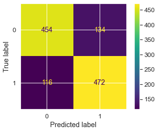

```python
# Confusion matrix on the training data

plot_confusion_matrix(LR_SM, X_train_SM, Y_train_SM)
```

So, True Positives are coming here is 472, that means 472 times our model has predicted correctly, that means it has predicted 1 as 1, and only 116 times it has predicted incorrectly.

```
<sklearn.metrics._plot.confusion_matrix.ConfusionMatrixDisplay at 0x2364ee73130>
```

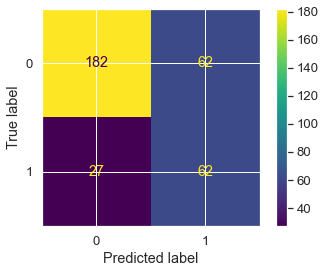

```python
# Confusion Matrix - Test data

plot_confusion_matrix(LR_SM, normalized_X_test, Y_test)
```

So, in test data, True Positives are coming here is 62, that means 62 times our model has predicted correctly, that means it has predicted 1 as 1, and only 27 times it has predicted incorrectly.

Similarly, True Negatives are 182 that means 182 times it has predicted 0 as 0 and only 62 times, the prediction was incorrect.

```python
# Predicting Probabilities

probs = LR_SM.predict_proba(X_train_SM)
```

```python
# keep probabilities for the positive outcome only

probs = probs[:, 1]
```

```python
# Calculate Area Under Curve

auc = roc_auc_score(Y_train_SM, probs)

print('AUC: %.3f' % auc)
```

```
AUC: 0.862
```

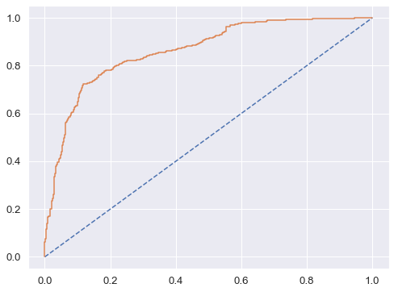

```python
# Calculate ROC curve

train_fpr, train_tpr, train_thresholds = roc_curve(Y_train_SM, probs)
plt.rcParams["figure.figsize"] = (8,6)
plt.plot([0, 1], [0, 1], linestyle='--')


# plot the roc curve for the model
plt.plot(train_fpr, train_tpr);
```

```python
#Accuracy score - for Test data

acc_test = LR_SM.score(normalized_X_test, Y_test)

acc_test
```

```
0.7327327327327328
```

So in the above model, the area under the curve is 86% that means the overall model performance is good.

Also, the confusion matrix and classification report the LR_SM Logistic Regression Model is giving the good results.

### Using GridSearchCV for Logistic Regression :-

```python
grid = {'penalty':['l2','none'], 'solver':['sag','lbfgs'], 'tol':[0.0001,0.00001]}

LR_grid = LogisticRegression(max_iter=10000, n_jobs=2)
```

```python
grid_search = GridSearchCV(estimator=LR_grid, param_grid = grid, cv=3, n_jobs=-1, scoring='f1')

grid_search.fit(X_train_SM, Y_train_SM)
```

```
GridSearchCV(cv=3, estimator=LogisticRegression(max_iter=10000, n_jobs=2),
             n_jobs=-1,
             param_grid={'penalty': ['l2', 'none'], 'solver': ['sag', 'lbfgs'],
                         'tol': [0.0001, 1e-05]},
             scoring='f1')
```

```python
print('Best Parameters from GridSearch:',grid_search.best_params_)

print('\nBest estimator from GridSearch:',grid_search.best_estimator_)
```

```
Best Parameters from GridSearch: {'penalty': 'l2', 'solver': 'sag', 'tol': 0.0001}

Best estimator from GridSearch: LogisticRegression(max_iter=10000, n_jobs=2, solver='sag')
```

```python
best_LR_model = grid_search.best_estimator_
```

```python
# Prediction - on Train data

Y_train_grid_predict = best_LR_model.predict(X_train_SM)

Y_test_grid_predict = best_LR_model.predict(normalized_X_test)
```

```python
# Predicting Probabilities - on Test data

Y_test_grid_predict_prob = best_LR_model.predict_proba(normalized_X_test)

pd.DataFrame(Y_test_grid_predict_prob).head()
```

|  | 0 | 1 |
| --- | --- | --- |
| 0 | 0.60 | 0.40 |
| 1 | 0.23 | 0.77 |
| 2 | 0.99 | 0.01 |
| 3 | 0.67 | 0.33 |
| 4 | 0.21 | 0.79 |

```
<sklearn.metrics._plot.confusion_matrix.ConfusionMatrixDisplay at 0x2364c8a79a0>
```

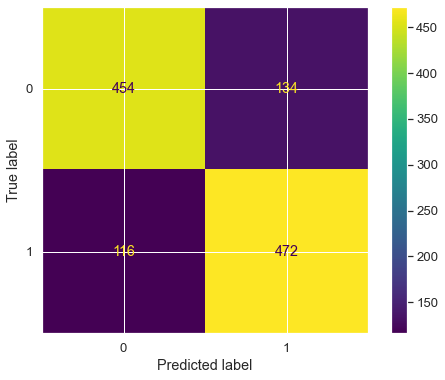

```python
# Confusion Matrix - Train data

plot_confusion_matrix(best_LR_model, X_train_SM, Y_train_SM)
```

```python
# Classification Report - Train data

print(classification_report(Y_train_SM, Y_train_grid_predict))
```

```
              precision    recall  f1-score   support

           0       0.80      0.77      0.78       588
           1       0.78      0.80      0.79       588

    accuracy                           0.79      1176
   macro avg       0.79      0.79      0.79      1176
weighted avg       0.79      0.79      0.79      1176
```

```
<sklearn.metrics._plot.confusion_matrix.ConfusionMatrixDisplay at 0x2364f025ca0>
```

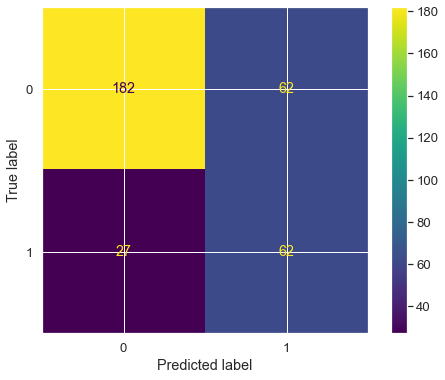

```python
# Confusion Matrix - Test data

plot_confusion_matrix(best_LR_model, normalized_X_test, Y_test)
```

```python
# Classification Report - Test data

print(classification_report(Y_test, Y_test_grid_predict))
```

```
              precision    recall  f1-score   support

           0       0.87      0.75      0.80       244
           1       0.50      0.70      0.58        89

    accuracy                           0.73       333
   macro avg       0.69      0.72      0.69       333
weighted avg       0.77      0.73      0.74       333
```

There is no change in the recall values and other matrices as well after using GridSearchCV.

This might not be the best model. We will check other models as well.

### KNN Model (k-nearest neighbors)

We will be building KNN model on re-sampled train sets.

```python
# Importing KNeighboursClassifier

KNN_model = KNeighborsClassifier()

KNN_model.fit(X_train_SM, Y_train_SM)
```

```
KNeighborsClassifier()
```

```python
# Predicting the model on Train set and check the model score

predicted_labels = KNN_model.predict(X_train_SM)

KNN_model_score = KNN_model.score(X_train_SM, Y_train_SM)
```

```python
predicted_labels_test = KNN_model.predict(normalized_X_test)

KNN_model_score_test = KNN_model.score(normalized_X_test, Y_test)
```

```python
KNN_model_score
```

```
0.9914965986394558
```

```python
KNN_model_score_test
```

```
0.9159159159159159
```

Accuracy is quite good. Let see the other metrics.

### Classification Report and Confusion Matrix :-

```python
# For train data

print('Confusion Matrix\n')

print(metrics.confusion_matrix(Y_train_SM, predicted_labels))

print('Classification Report\n')

print(metrics.classification_report(Y_train_SM, predicted_labels))
```

```
Confusion Matrix

[[578  10]
 [  0 588]]
Classification Report

              precision    recall  f1-score   support

           0       1.00      0.98      0.99       588
           1       0.98      1.00      0.99       588

    accuracy                           0.99      1176
   macro avg       0.99      0.99      0.99      1176
weighted avg       0.99      0.99      0.99      1176
```

```python
# For test data

print('Confusion Matrix\n')

print(metrics.confusion_matrix(Y_test, predicted_labels_test))

print('Classification Report\n')

print(metrics.classification_report(Y_test, predicted_labels_test))
```

```
Confusion Matrix

[[216  28]
 [  0  89]]
Classification Report

              precision    recall  f1-score   support

           0       1.00      0.89      0.94       244
           1       0.76      1.00      0.86        89

    accuracy                           0.92       333
   macro avg       0.88      0.94      0.90       333
weighted avg       0.94      0.92      0.92       333
```

Recall Value is much better than the logistic Regression model.

### AUC ROC Curve :-

```
Area Under Curve: 1.000
```

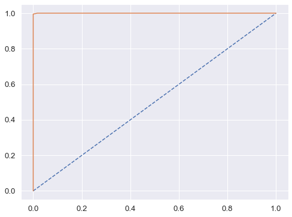

```python
# AUC ROC Curve on Train data

probs_train = KNN_model.predict_proba(X_train_SM)

probs_train = probs_train[:, 1]

auc=roc_auc_score(Y_train_SM,probs_train)


print("Area Under Curve: %.3f " % auc)
train_fpr ,train_tpr, train_thresholds= roc_curve(Y_train_SM, probs_train)
plt.plot([0,1],[0,1],linestyle='--')
plt.plot(train_fpr,train_tpr);
```

Since, the AUC = 100%, which is too good and it means that the KNN based classifier's performance is better for the model at distinguishing between the positive and negative classes.

### Naive Bayes Model

```python
# Fit the model into training data

NB_model = GaussianNB()

NB_model.fit(X_train_SM, Y_train_SM)
```

```
GaussianNB()
```

### Let see the performance of our model with training data :-

```python
NB_train_predict = NB_model.predict(X_train_SM)


print("Model Accuracy: {0:.2f}".format(metrics.accuracy_score(Y_train_SM, NB_train_predict)))
```

```
Model Accuracy: 0.73
```

### Let see the performance of our model with testing data :-

```python
NB_test_predict = NB_model.predict(normalized_X_test)


print("Model Accuracy: {0:.2f}".format(metrics.accuracy_score(Y_test, NB_test_predict)))
```

```
Model Accuracy: 0.70
```

### Confusion Matrix & Classification Report :-

```
Confusion Matrix:
```

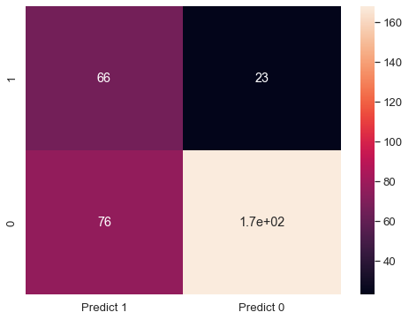

```python
print("Confusion Matrix:\n")

CM = metrics.confusion_matrix(Y_test, NB_test_predict, labels=[1, 0])

df_CM = pd.DataFrame(CM, index = [i for i in ["1","0"]],
                  columns = [i for i in ["Predict 1","Predict 0"]])


# Plotting the matrix
plt.figure(figsize = (8,6))
sns.heatmap(df_CM, annot=True)
```

```python
print("Classification Report")
print(metrics.classification_report(Y_test, NB_test_predict, labels=[1, 0]))
```

```
Classification Report
              precision    recall  f1-score   support

           1       0.46      0.74      0.57        89
           0       0.88      0.69      0.77       244

    accuracy                           0.70       333
   macro avg       0.67      0.72      0.67       333
weighted avg       0.77      0.70      0.72       333
```

## 2. Model Tuning

1. Ensemble modeling, wherever applicable.
2. Any other model tuning measures(if applicable).
3. Interpretation of the most optimum model and its implication on the business.

### Random Forest

```python
rfcl = RandomForestClassifier(n_estimators=301, oob_score = True, max_depth = 10, max_features = 5, min_samples_leaf = 50, min_samples_split=110)

rfcl = rfcl.fit(X_train_SM, Y_train_SM)
```

n_estimators = number of trees, that we want to build within the RandomForestClassifier.

Out of bag (OOB) score is a way of validating the Random forest model. OOB score is computed as the number of correctly predicted rows from the out of bag sample.

max_features will be used to select randomly features from the available number of features.

```python
rfcl
```

```
RandomForestClassifier(max_depth=10, max_features=5, min_samples_leaf=50,
                       min_samples_split=110, n_estimators=301, oob_score=True)
```

```python
rfcl.oob_score_
```

```
0.826530612244898
```

```python
#Checking the error rate in %:

print('Error_rate(in %) :', 1- (rfcl.oob_score_)) #OOB Error is the number of wrongly classifying the OOB Sample.
```

```
Error_rate(in %) : 0.173469387755102
```

For the above specified grid parameters, we got the rfcl model with oob score around 83% and error rate 17%, which shows the model is good to go for further evaluation.

### Getting the Feature Importances :-

```python
print (pd.DataFrame(rfcl.feature_importances_, columns = ["Imp"],
                    index = X_train_SM.columns).sort_values('Imp',ascending=False))
```

```
                            Imp
YA_view_on_CP              0.21
TL_rec_on_OS_checkin       0.18
following_CP_Yes           0.16
Adult_flag                 0.10
DA_mins_spend_on_CP        0.09
TL_done_on_OS_checkin      0.07
week_since_last_OS_checkin 0.05
travelling_network_rating  0.04
YA_OS_checkin              0.04
YA_comment_on_CP           0.04
members_in_fam             0.02
working_flag_Yes           0.00
pref_loc_type_Big Cities   0.00
pref_loc_type_Other        0.00
```

### Let's Now use Ensemble techniques : Bagging, Ada Boosting, GradientBoost :-

```python
#Let's first look by use Bagging

#we will be using random forest as base_estimator

bgcl = BaggingClassifier(base_estimator=rfcl, n_estimators=50,random_state=1)


# Fit the model into training data
bgcl = bgcl.fit(X_train_SM, Y_train_SM)
```

```
0.7297297297297297
```

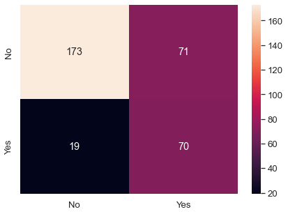

```python
# Let's predict on test set

Y_test_predict = bgcl.predict(normalized_X_test)

print(bgcl.score(normalized_X_test , Y_test))

cm=metrics.confusion_matrix(Y_test, Y_test_predict,labels=[0, 1])

df_cm = pd.DataFrame(cm, index = [i for i in ["No","Yes"]],
                  columns = [i for i in ["No","Yes"]])

plt.figure(figsize = (7,5))
sns.heatmap(df_cm, annot=True ,fmt='g')
```

### Ada Boosting

```python
# Defining the ada boosting classifier

abcl = AdaBoostClassifier(n_estimators=10, random_state=1)

#fit the model to the train data
abcl = abcl.fit(X_train_SM, Y_train_SM)
```

```
0.44744744744744747
```

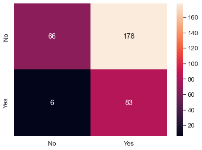

```python
Y_predict_1 = abcl.predict(normalized_X_test)

print(abcl.score(normalized_X_test , Y_test))

cm = metrics.confusion_matrix(Y_test, Y_predict_1,labels=[0, 1])

df_cm_1 = pd.DataFrame(cm, index = [i for i in ["No","Yes"]],
                  columns = [i for i in ["No","Yes"]])
plt.figure(figsize = (7,5))
sns.heatmap(df_cm_1, annot=True ,fmt='g')
```

### Gradient Boost

```python
gbcl = GradientBoostingClassifier(n_estimators = 50,random_state=1)
gbcl = gbcl.fit(X_train_SM, Y_train_SM)
```

```python
Y_predict_2 = gbcl.predict(normalized_X_test)
print(gbcl.score(normalized_X_test, Y_test))
```

```
0.6126126126126126
```

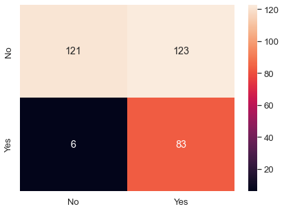

```python
cm = metrics.confusion_matrix(Y_test, Y_predict_2,labels=[0, 1])

df_cm_2 = pd.DataFrame(cm, index = [i for i in ["No","Yes"]],
                  columns = [i for i in ["No","Yes"]])
plt.figure(figsize = (7,5))
sns.heatmap(df_cm_2, annot=True ,fmt='g')
```

### Calculation for Model Building : For Mobile users

### Train-Test Split :-

```python
#Now, let's separate dependent and independent variables

x = data_mobile_dummy.drop('Taken_product_Yes', axis=1)

y = data_mobile_dummy[['Taken_product_Yes']]
```

```python
# Split the data into test and train sets in 70:30 ratio

x_train, x_test, y_train, y_test = train_test_split(x, y, test_size = 0.30, random_state = 11)
```

```python
print('Shape of x_train:',x_train.shape)

x_train.head().T
```

```
Shape of x_train: (6542, 17)
```

|  | 4471 | 10698 | 5645 | 8744 | 5377 |
| --- | --- | --- | --- | --- | --- |
| YA_view_on_CP | 287.00 | 403.00 | 346.00 | 245.00 | 301.00 |
| TL_done_on_OS_checkin | 22885.00 | 52192.00 | 44738.00 | 48062.00 | 11554.00 |
| YA_OS_checkin | 29.00 | 4.00 | 1.00 | 5.00 | 1.00 |
| members_in_fam | 5.00 | 2.00 | 3.00 | 4.00 | 4.00 |
| YA_comment_on_CP | 58.00 | 47.00 | 79.00 | 61.00 | 95.00 |
| TL_rec_on_OS_checkin | 2461.00 | 16572.00 | 10411.00 | 9687.00 | 2447.00 |
| week_since_last_OS_checkin | 1.00 | 4.00 | 6.00 | 8.00 | 3.00 |
| travelling_network_rating | 4.00 | 4.00 | 2.00 | 2.00 | 3.00 |
| Adult_flag | 0.00 | 0.00 | 1.00 | 0.00 | 1.00 |
| DA_mins_spend_on_CP | 15.00 | 33.00 | 19.00 | 8.00 | 7.00 |
| pref_loc_type_Big Cities | 0.00 | 0.00 | 0.00 | 0.00 | 0.00 |
| pref_loc_type_Entertainment | 0.00 | 0.00 | 0.00 | 0.00 | 0.00 |
| pref_loc_type_Financial | 1.00 | 0.00 | 1.00 | 0.00 | 1.00 |
| pref_loc_type_Medical | 0.00 | 0.00 | 0.00 | 0.00 | 0.00 |
| pref_loc_type_Other | 0.00 | 0.00 | 0.00 | 0.00 | 0.00 |
| following_CP_Yes | 0.00 | 0.00 | 1.00 | 0.00 | 0.00 |
| working_flag_Yes | 0.00 | 0.00 | 0.00 | 1.00 | 1.00 |

```python
# Normalization of x_train

normalized_x_train = pd.DataFrame(StandardScaler().fit_transform(x_train),columns = x_train.columns)
```

```python
print('Shape of y_train:',y_train.shape)

y_train.head().T
```

```
Shape of y_train: (6542, 1)
```

|  | 4471 | 10698 | 5645 | 8744 | 5377 |
| --- | --- | --- | --- | --- | --- |
| Taken_product_Yes | 0 | 0 | 0 | 0 | 0 |

```python
print('Shape of x_test:',x_test.shape)

x_test.head().T
```

```
Shape of x_test: (2805, 17)
```

|  | 8355 | 4104 | 6362 | 3270 | 11676 |
| --- | --- | --- | --- | --- | --- |
| YA_view_on_CP | 222.00 | 301.00 | 241.00 | 324.00 | 205.00 |
| TL_done_on_OS_checkin | 11627.00 | 15717.00 | 47778.00 | 19609.00 | 5545.00 |
| YA_OS_checkin | 17.00 | 16.00 | 13.00 | 10.00 | 1.00 |
| members_in_fam | 3.00 | 3.00 | 4.00 | 4.00 | 3.00 |
| YA_comment_on_CP | 55.00 | 99.00 | 51.00 | 96.00 | 111.00 |
| TL_rec_on_OS_checkin | 7995.00 | 7998.00 | 4237.00 | 5301.00 | 2924.00 |
| week_since_last_OS_checkin | 1.00 | 8.00 | 2.00 | 2.00 | 1.00 |
| travelling_network_rating | 1.00 | 4.00 | 3.00 | 2.00 | 4.00 |
| Adult_flag | 0.00 | 0.00 | 0.00 | 1.00 | 0.00 |
| DA_mins_spend_on_CP | 10.00 | 21.00 | 9.00 | 11.00 | 14.00 |
| pref_loc_type_Big Cities | 0.00 | 0.00 | 0.00 | 0.00 | 0.00 |
| pref_loc_type_Entertainment | 0.00 | 0.00 | 0.00 | 0.00 | 0.00 |
| pref_loc_type_Financial | 0.00 | 1.00 | 0.00 | 1.00 | 0.00 |
| pref_loc_type_Medical | 0.00 | 0.00 | 0.00 | 0.00 | 0.00 |
| pref_loc_type_Other | 1.00 | 0.00 | 0.00 | 0.00 | 0.00 |
| following_CP_Yes | 0.00 | 1.00 | 0.00 | 0.00 | 0.00 |
| working_flag_Yes | 0.00 | 0.00 | 0.00 | 0.00 | 0.00 |

```python
# Normalization of x_test

normalized_x_test = pd.DataFrame(StandardScaler().fit_transform(x_test),columns = x_test.columns)
```

```python
print('Shape of y_test:',y_test.shape)

y_test.head()
```

```
Shape of y_test: (2805, 1)
```

|  | Taken_product_Yes |
| --- | --- |
| 8355 | 0 |
| 4104 | 0 |
| 6362 | 1 |
| 3270 | 0 |
| 11676 | 0 |

```python
data_mobile_dummy['Taken_product_Yes'].value_counts()
```

```
0    7930
1    1417
Name: Taken_product_Yes, dtype: int64
```

### Need of applying SMOTE :-

As per our analysis, we got to know that the data is more towards the negative side, like majority of the users have not taken our product.This clearly means that data is in imbalance state.

Standard ML techniques such as Decision Tree and Logistic Regression have a bias towards the majority class, and they tend to ignore the minority class. They tend only to predict the majority class, hence, having major misclassification of the minority class in comparison with the majority class. In more technical words, if we have imbalanced data distribution in our dataset then our model becomes more prone to the case when minority class has negligible or very lesser recall.

So we will be using a over sampling technique called SMOTE to handle imbalanced data.

### Logistic Regression Model (with default values) : On imbalance data

```python
# Let us first now train the data without handling imbalance problem

LR_mob = LogisticRegression()
```

```python
# Now let's fit the model on training data

LR_mob.fit(normalized_x_train, y_train)
```

```
LogisticRegression()
```

```python
# Prdecition on training data

y_train_predict = LR_mob.predict(normalized_x_train)
```

```python
# Prdecition on testing data

y_test_predict = LR_mob.predict(normalized_x_test)
```

```python
# Getting the predicted classes and probs

y_test_predict_prob = LR_mob.predict_proba(normalized_x_test)
```

```python
# Model Evaluation - Accuracy on training data

LR_mob.score(normalized_x_train, y_train)
```

```
0.8720574747783553
```

```python
# Classification Report - training data

print(classification_report(y_train, y_train_predict))
```

```
              precision    recall  f1-score   support

           0       0.88      0.99      0.93      5550
           1       0.75      0.23      0.36       992

    accuracy                           0.87      6542
   macro avg       0.82      0.61      0.64      6542
weighted avg       0.86      0.87      0.84      6542
```

```python
# Classification Report - testing data

print(classification_report(y_test, y_test_predict))
```

```
              precision    recall  f1-score   support

           0       0.87      0.98      0.92      2380
           1       0.66      0.19      0.30       425

    accuracy                           0.86      2805
   macro avg       0.77      0.59      0.61      2805
weighted avg       0.84      0.86      0.83      2805
```

### Applying SMOTE

Now, we will apply the imbalanced data handling technique, called SMOTE and test it's accuracy and recall results.

```python
SM = SMOTE(random_state = 2)

x_train_SM, y_train_SM = SM.fit_sample(normalized_x_train, y_train)
```

```python
print('After OverSampling, the shape of x_train:',x_train_SM.shape)

print('After OverSampling, the shape of y_train:',y_train_SM.shape)
```

```
After OverSampling, the shape of x_train: (11100, 17)
After OverSampling, the shape of y_train: (11100, 1)
```

### Logistic Regression Model (with default values) : On balanced data - After applying SMOTE - Oversampling

Now we will again make the model again and check the recall values for majority and minority classes.

```python
LR_mob_SM = LogisticRegression()
```

```python
# Now let's fit the model on train data

LR_mob_SM.fit(x_train_SM, y_train_SM)
```

```
LogisticRegression()
```

```python
# Prdecition - on Train data

y_train_predict_SM = LR_mob_SM.predict(x_train_SM)
```

```python
# Prdecition - on Test data

y_test_predict_SM = LR_mob_SM.predict(normalized_x_test)
```

```python
# Model Evaluation - Accuracy on Train data

LR_mob_SM.score(x_train_SM, y_train_SM)
```

```
0.7296396396396396
```

```python
# Classification Report - Train data

print(classification_report(y_train_SM, y_train_predict_SM))
```

```
              precision    recall  f1-score   support

           0       0.73      0.72      0.73      5550
           1       0.73      0.74      0.73      5550

    accuracy                           0.73     11100
   macro avg       0.73      0.73      0.73     11100
weighted avg       0.73      0.73      0.73     11100
```

```python
# Classification Report - Test data

print(classification_report(y_test, y_test_predict_SM))
```

```
              precision    recall  f1-score   support

           0       0.94      0.72      0.82      2380
           1       0.32      0.74      0.45       425

    accuracy                           0.72      2805
   macro avg       0.63      0.73      0.63      2805
weighted avg       0.85      0.72      0.76      2805
```

Now the difference is clear, that after over-sampling, the accuracy has been reduced, But as we know that the accuracy is not the good predictor here in our case because we are dealing with less classes and it is also a classification algorithm.

So here we will focus more on improving our recall. Now, the recall for the minority class has been increased a lot, and it is very good. But the recall for the majority class has been decreased, this is due the fact that now that there is a balance in both the classes.

### Logistic Regression Model (Customized Values) : On balanced data - After applying SMOTE - Oversampling

As we have build the previous model with it's default values. There might be chances of more better model than this, with some customized parameters for the logistic regression model.

```python
# Fit the Logistic Regression model

LR_mob_SM_custom = LogisticRegression(solver='lbfgs', penalty='none', max_iter=100000, n_jobs=2, verbose=True)

LR_mob_SM_custom.fit(x_train_SM, y_train_SM)
```

```
[Parallel(n_jobs=2)]: Using backend LokyBackend with 2 concurrent workers.
[Parallel(n_jobs=2)]: Done   1 out of   1 | elapsed:    1.9s finished
```

```
LogisticRegression(max_iter=100000, n_jobs=2, penalty='none', verbose=True)
```

```python
# Prdecition - on Train data

y_train_predict_SM_custom = LR_mob_SM_custom.predict(x_train_SM)
```

```python
# Prdecition - on Test data

y_test_predict_SM_custom = LR_mob_SM_custom.predict(normalized_x_test)
```

```python
# Model Evaluation - Accuracy - for Train data

LR_mob_SM_custom.score(x_train_SM, y_train_SM)
```

```
0.7296396396396396
```

```python
# Classification Report - Train data

print(classification_report(y_train_SM, y_train_predict_SM_custom))
```

```
              precision    recall  f1-score   support

           0       0.73      0.72      0.73      5550
           1       0.73      0.74      0.73      5550

    accuracy                           0.73     11100
   macro avg       0.73      0.73      0.73     11100
weighted avg       0.73      0.73      0.73     11100
```

```python
# Classification Report - Test data

print(classification_report(y_test, y_test_predict_SM_custom))
```

```
              precision    recall  f1-score   support

           0       0.94      0.72      0.82      2380
           1       0.32      0.74      0.45       425

    accuracy                           0.72      2805
   macro avg       0.63      0.73      0.63      2805
weighted avg       0.85      0.72      0.76      2805
```

### Confusion Matrix, AUC, ROC for the Model :-

```
<sklearn.metrics._plot.confusion_matrix.ConfusionMatrixDisplay at 0x23650cda2b0>
```

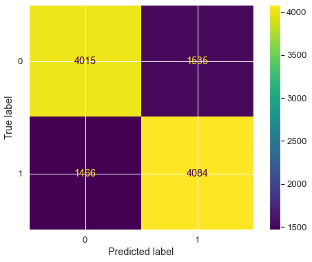

```python
## Confusion matrix - Train data

plot_confusion_matrix(LR_mob_SM, x_train_SM, y_train_SM)
```

```
<sklearn.metrics._plot.confusion_matrix.ConfusionMatrixDisplay at 0x23650d71fa0>
```

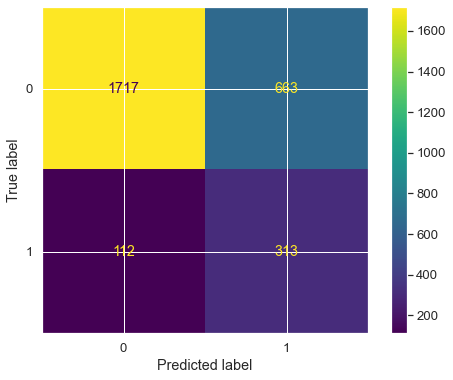

```python
## Confusion matrix - Test data

plot_confusion_matrix(LR_mob_SM, normalized_x_test, y_test)
```

```python
# Predicting Probabilities

probs = LR_mob_SM.predict_proba(x_train_SM)
```

```
AUC: 0.794
```

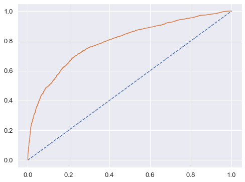

```python
# Keep probabilities for the positive outcome only

probs = probs[:, 1]

# Calculate Area Under Curve

auc = roc_auc_score(y_train_SM, probs)

print('AUC: %.3f' % auc)

# Calculate ROC curve

train_fpr, train_tpr, train_thresholds = roc_curve(y_train_SM, probs)
plt.rcParams["figure.figsize"] = (8,6)
plt.plot([0, 1], [0, 1], linestyle='--')


# Plot the roc curve for the model
plt.plot(train_fpr, train_tpr);
```

```python
#Accuracy score - for Test data

acc_test = LR_mob_SM.score(normalized_x_test, y_test)

acc_test
```

```
0.7237076648841355
```

Also, the confusion matrix and classification report the LR_mob_SM Logistic Regression Model is giving the good results.

### Using GridSearchCV for Logistic Regression :-

```python
grid = {'penalty':['l2','none'], 'solver':['sag','lbfgs'], 'tol':[0.0001,0.00001]}

LR_mob_grid = LogisticRegression(max_iter=10000, n_jobs=2)

grid_search = GridSearchCV(estimator=LR_mob_grid, param_grid = grid, cv=3, n_jobs=-1, scoring='f1')

grid_search.fit(x_train_SM, y_train_SM)
```

```
GridSearchCV(cv=3, estimator=LogisticRegression(max_iter=10000, n_jobs=2),
             n_jobs=-1,
             param_grid={'penalty': ['l2', 'none'], 'solver': ['sag', 'lbfgs'],
                         'tol': [0.0001, 1e-05]},
             scoring='f1')
```

```python
print('Best Parameters from GridSearch:',grid_search.best_params_)

print('\nBest estimator from GridSearch:',grid_search.best_estimator_)

best_LR_mob_model = grid_search.best_estimator_
```

```
Best Parameters from GridSearch: {'penalty': 'l2', 'solver': 'sag', 'tol': 0.0001}

Best estimator from GridSearch: LogisticRegression(max_iter=10000, n_jobs=2, solver='sag')
```

```python
# Prediction - Train data

y_train_grid_predict = best_LR_mob_model.predict(x_train_SM)
y_test_grid_predict = best_LR_mob_model.predict(normalized_x_test)
```

```python
# Getting the probabilities - Test data

y_test_grid_predict_prob = best_LR_mob_model.predict_proba(normalized_x_test)

pd.DataFrame(y_test_grid_predict_prob).head()
```

|  | 0 | 1 |
| --- | --- | --- |
| 0 | 0.54 | 0.46 |
| 1 | 0.15 | 0.85 |
| 2 | 0.57 | 0.43 |
| 3 | 0.80 | 0.20 |
| 4 | 0.60 | 0.40 |

```
<sklearn.metrics._plot.confusion_matrix.ConfusionMatrixDisplay at 0x23650d7e670>
```

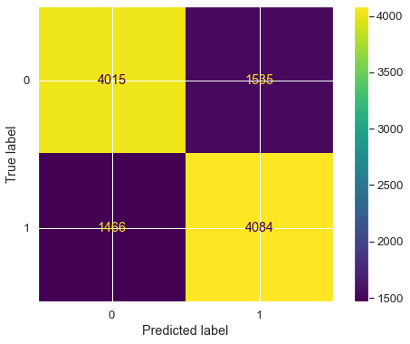

```python
# Confusion Matrix - Train data

plot_confusion_matrix(best_LR_mob_model, x_train_SM, y_train_SM)
```

```python
# Classification Report - Train data

print(classification_report(y_train_SM, y_train_grid_predict))
```

```
              precision    recall  f1-score   support

           0       0.73      0.72      0.73      5550
           1       0.73      0.74      0.73      5550

    accuracy                           0.73     11100
   macro avg       0.73      0.73      0.73     11100
weighted avg       0.73      0.73      0.73     11100
```

```
<sklearn.metrics._plot.confusion_matrix.ConfusionMatrixDisplay at 0x23650bf02e0>
```

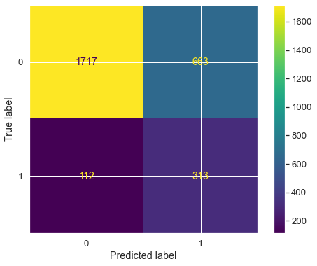

```python
# Confusion Matrix - Test data

plot_confusion_matrix(best_LR_mob_model, normalized_x_test, y_test)
```

```python
# Classification Report - Test data

print(classification_report(y_test, y_test_grid_predict))
```

```
              precision    recall  f1-score   support

           0       0.94      0.72      0.82      2380
           1       0.32      0.74      0.45       425

    accuracy                           0.72      2805
   macro avg       0.63      0.73      0.63      2805
weighted avg       0.85      0.72      0.76      2805
```

### KNN Model (k-nearest neighbors)

We will be building KNN model on re-sampled train sets.

```python
# Importing KNeighboursClassifier

KNN_mob_model = KNeighborsClassifier()

KNN_mob_model.fit(x_train_SM, y_train_SM)
```

```
KNeighborsClassifier()
```

```python
#let's predict the model on train set and check the model score

predicted_labels = KNN_mob_model.predict(x_train_SM)

KNN_mob_model_score = KNN_mob_model.score(x_train_SM, y_train_SM)

KNN_mob_model_score
```

```
0.9808108108108108
```

### Classification Report & Confusion Matrix :-

```python
print('Confusion Matrix\n')

print(metrics.confusion_matrix(y_train_SM, predicted_labels))

print('Classification Report\n')

print(metrics.classification_report(y_train_SM, predicted_labels))
```

```
Confusion Matrix

[[5342  208]
 [   5 5545]]
Classification Report

              precision    recall  f1-score   support

           0       1.00      0.96      0.98      5550
           1       0.96      1.00      0.98      5550

    accuracy                           0.98     11100
   macro avg       0.98      0.98      0.98     11100
weighted avg       0.98      0.98      0.98     11100
```

### AUC ROC Curve on Train data :-

```
Area Under Curve: 1.000
```

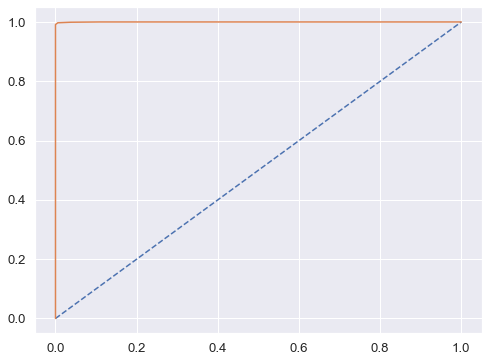

```python
probs_train = KNN_mob_model.predict_proba(x_train_SM)

probs_train = probs_train[:, 1]

auc=roc_auc_score(y_train_SM,probs_train)

print("Area Under Curve: %.3f " % auc)
train_fpr ,train_tpr, train_thresholds= roc_curve(y_train_SM, probs_train)
plt.plot([0,1],[0,1],linestyle='--')
plt.plot(train_fpr,train_tpr);
```

### Naive Bayes Model

```python
# Fit the model into training data

NB_mob_model = GaussianNB()

NB_mob_model.fit(x_train_SM, y_train_SM)
```

```
GaussianNB()
```

```python
NB_train_predict = NB_mob_model.predict(x_train_SM)

print("Model Accuracy: {0:.2f}".format(metrics.accuracy_score(y_train_SM, NB_train_predict)))
```

```
Model Accuracy: 0.69
```

```python
# Prediction - on Test data

NB_test_predict = NB_mob_model.predict(normalized_x_test)
```

```python
print("Model Accuracy: {0:.2f}".format(metrics.accuracy_score(y_test, NB_test_predict)))
```

```
Model Accuracy: 0.66
```

```
Confusion Matrix:
```

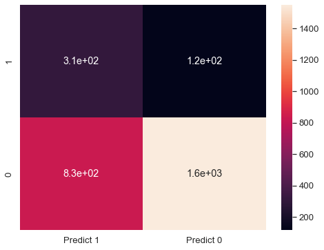

```python
# Confusion Matrix

print("Confusion Matrix:\n")

CM = metrics.confusion_matrix(y_test, NB_test_predict, labels=[1, 0])

df_CM = pd.DataFrame(CM, index = [i for i in ["1","0"]],
                  columns = [i for i in ["Predict 1","Predict 0"]])

# Plotting the matrix
plt.figure(figsize = (8,6))
sns.heatmap(df_CM, annot=True)
```

```
Classification Report
              precision    recall  f1-score   support

           1       0.27      0.73      0.40       425
           0       0.93      0.65      0.77      2380

    accuracy                           0.66      2805
   macro avg       0.60      0.69      0.58      2805
weighted avg       0.83      0.66      0.71      2805
```

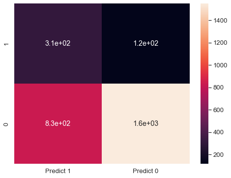

```python
# Plotting the matrix
plt.figure(figsize = (8,6))
sns.heatmap(df_CM, annot=True)

print("Classification Report")
print(metrics.classification_report(y_test, NB_test_predict, labels=[1, 0]))
```

## 2. Model Tuning

1. Ensemble modeling, wherever applicable.
2. Any other model tuning measures(if applicable).
3. Interpretation of the most optimum model and its implication on the business.

### Random Forest

```python
rfcl_mob = RandomForestClassifier(n_estimators=301, oob_score = True, max_depth = 10, max_features = 5, min_samples_leaf = 50, min_samples_split=110)

rfcl_mob = rfcl_mob.fit(x_train_SM, y_train_SM)
```

n_estimators = number of trees, that we want to build within the RandomForestClassifier.

Out of bag (OOB) score is a way of validating the Random forest model. OOB score is computed as the number of correctly predicted rows from the out of bag sample.

max_features will be used to select randomly features from the available number of features.

```python
rfcl_mob
```

```
RandomForestClassifier(max_depth=10, max_features=5, min_samples_leaf=50,
                       min_samples_split=110, n_estimators=301, oob_score=True)
```

```python
rfcl_mob.oob_score_
```

```
0.8774774774774775
```

```python
#Checking the error rate in %:

print('Error_rate(in %) :', 1- (rfcl_mob.oob_score_)) #OOB Error is the number of wrongly classifying the OOB Sample.
```

```
Error_rate(in %) : 0.12252252252252249
```

### Getting the Feature Importances :-

```python
print (pd.DataFrame(rfcl_mob.feature_importances_, columns = ["Imp"],
                    index = x_train_SM.columns).sort_values('Imp',ascending=False))
```

```
                             Imp
following_CP_Yes            0.19
TL_rec_on_OS_checkin        0.17
Adult_flag                  0.14
YA_view_on_CP               0.09
week_since_last_OS_checkin  0.08
DA_mins_spend_on_CP         0.08
TL_done_on_OS_checkin       0.07
travelling_network_rating   0.05
YA_OS_checkin               0.05
members_in_fam              0.03
YA_comment_on_CP            0.03
working_flag_Yes            0.00
pref_loc_type_Entertainment 0.00
pref_loc_type_Medical       0.00
pref_loc_type_Financial     0.00
pref_loc_type_Big Cities    0.00
pref_loc_type_Other         0.00
```

### Let's Now use Ensemble techniques : Bagging, Ada Boosting, GradientBoost :-

```python
#Let's first look by use Bagging

#we will be using random forest as base_estimator

bgcl_mob = BaggingClassifier(base_estimator=rfcl_mob, n_estimators=50,random_state=1)
```

```python
# Fit the model into training data
bgcl_mob = bgcl_mob.fit(x_train_SM, y_train_SM)
```

```python
# Let's predict on test set

y_test_predict = bgcl_mob.predict(normalized_x_test)
```

```python
print(bgcl_mob.score(normalized_x_test , y_test))
```

```
0.8156862745098039
```

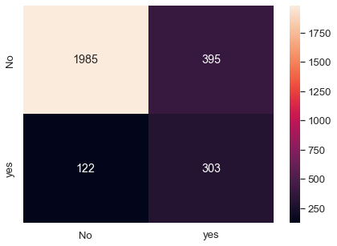

```python
cm=metrics.confusion_matrix(y_test, y_test_predict,labels=[0, 1])

df_cm = pd.DataFrame(cm, index = [i for i in ["No","yes"]],
                  columns = [i for i in ["No","yes"]])

plt.figure(figsize = (7,5))
sns.heatmap(df_cm, annot=True ,fmt='g')
```

### Ada Boosting

```python
# Defining the ada boosting classifier

abcl_mob = AdaBoostClassifier(n_estimators=10, random_state=1)
```

```python
#fit the model to the train data

abcl_mob = abcl_mob.fit(x_train_SM, y_train_SM)
```

```python
# Prediction on - Test data

y_predict_1 = abcl_mob.predict(normalized_x_test)

print(abcl_mob.score(normalized_x_test , y_test))
```

```
0.6880570409982175
```

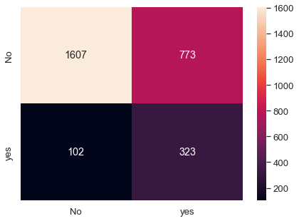

```python
cm = metrics.confusion_matrix(y_test, y_predict_1,labels=[0, 1])

df_cm_1 = pd.DataFrame(cm, index = [i for i in ["No","yes"]],
                  columns = [i for i in ["No","yes"]])
plt.figure(figsize = (7,5))
sns.heatmap(df_cm_1, annot=True ,fmt='g')
```

### Gradient Boost

```python
gbcl_mob = GradientBoostingClassifier(n_estimators = 50,random_state=1)

# Fit the model on Train data
gbcl_mob = gbcl_mob.fit(x_train_SM, y_train_SM)
```

```python
# Prediction - on Test data

y_predict_2 = gbcl_mob.predict(normalized_x_test)
print(gbcl_mob.score(normalized_x_test, y_test))
```

```
0.5572192513368984
```

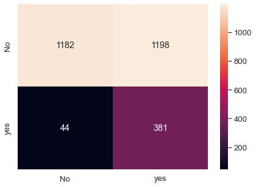

```python
cm = metrics.confusion_matrix(y_test, y_predict_2,labels=[0, 1])

df_cm_2 = pd.DataFrame(cm, index = [i for i in ["No","yes"]],
                  columns = [i for i in ["No","yes"]])
plt.figure(figsize = (7,5))
sns.heatmap(df_cm_2, annot=True ,fmt='g')
```